# About

''' date created: 2018-04-09

go from many csv files to a top k index fund return '''

```python
import numpy as np
import pandas as pd
import glob
import matplotlib.pyplot as plt
import seaborn as sns
%matplotlib inline
```

# initial dates

```python
df0 = pd.read_csv('../../datasets/crypto-index-fund/CryptoData.csv', parse_dates=True)
```

```python
df0.date = pd.to_datetime(df0.date)
```

```python
initialdate_per_coin = df0.groupby('symbol').date.min()
initialdate_per_coin.to_csv('initialdate_per_coin.csv')
```

```python
coins_top10today = ['BTC', 'ETH', 'XRP', 'BCH', 'LTC',
                   'EOS', 'ADA', 'XLM', 'MIOTA', 'NEO']
initialdate_per_coin.T[coins_top10today]
```

```
symbol
BTC     2013-04-28
ETH     2015-08-07
XRP     2013-08-04
BCH     2017-07-23
LTC     2013-04-28
EOS     2017-07-01
ADA     2017-10-01
XLM     2014-08-05
MIOTA   2017-06-13
NEO     2016-09-09
Name: date, dtype: datetime64[ns]
```

```python
del df0
```

# import

```python
df = pd.read_csv('../../datasets/crypto-index-fund/CryptoDataWide.csv', parse_dates=True)
```

```python
# index date
df['date'] = pd.to_datetime(df.date)
df.set_index('date', inplace=True)
```

```python
# begin at the start of a month
# och gör det att binarizer inte ger summa > 10 för dom första raderna? ngn bugg i den annars.
df = df.loc['2013-05-08':]
```

# create matrices: price, mcap, volume

```python
price_mat = df.filter(regex='^open.').fillna(0)
mcap_mat = df.filter(regex='^market').fillna(0)
volumes = df.filter(regex='^volume').fillna(0)
```

```python
names = [n.replace('open.', '') for n in price_mat.columns]
```

```python
price_mat.columns = names
mcap_mat.columns = names
volumes.columns = names
```

```python
T = price_mat.shape[0]
nr_coins = price_mat.shape[1]
price_mat.shape
```

```
(1800, 1562)
```

todo: gör dictionary med name & symbol. jag föredrar symbol.

## check

```python
# comparisons below => looked ok
mcap_mat.loc['2018-04-01', 'Bitcoin'], #116889698943 from online
price_mat.loc['2018-04-01', 'Bitcoin'] # from online $6,895.74
mcap_mat.loc['2018-04-01', 'Litecoin'] # $6,440,675,643from online
price_mat.loc['2018-04-01', 'Litecoin'] # $115.25      from online
mcap_mat.loc['2018-04-01', 'Ripple'] #  $19,620,488,346  from online
price_mat.loc['2018-04-01', 'Ripple'] # $0.50      from online
```

```
0.51385400000000003
```

```python
# compare all coins last 5 days with coinmarketcap.com
# price_mat.tail()
# mcap_mat.tai()
```

comparing with https://coinmarketcap.com/historical/20180408/ we have the correct cols now: market cap is 45 million USD and our dataset tells us 36 million so that's ok.

```python
if True==0:
    price_mat['Ethereum'].plot()
    plt.title('Ethereum price')
    plt.show()
```

For more checks, see coins2_20180415_1017.html

# monthly

we use monthly prices

```python
# backup
daily_price_mat = price_mat
daily_mcap_mat = mcap_mat
# month_price_mat = daily_price_mat.resample('M', convention='start').asfreq()
# month_mcap_mat = daily_mcap_mat.resample('M', convention='start').asfreq()
```

```python
# monthly data: the 10th
month_price_mat = daily_price_mat.loc[daily_price_mat.index.day == 10]
month_mcap_mat = daily_mcap_mat.loc[daily_mcap_mat.index.day == 10]
```

```python
# choose
freq = 'Monthly'

if freq == 'Monthly':
    price_mat = month_price_mat
    mcap_mat = month_mcap_mat
else:
    price_mat = daily_price_mat
    mcap_mat = daily_mcap_mat
```

```python
mcap_mat.shape
```

```
(60, 1562)
```

# choose nr of coins in the fund

```python
p = 10
```

# create weights and coinlist

fundret = return matrix *weights.shift(1) fundret = fundret.T.sum() måste vara korrekt. weigths = mcap* binary (& sen normera).

```python
def top_binarizer(row, p):
    """
    Return 1 if a coin's mcap is within top p=10
    return 0 otherwise
    """
    t = p-1
    row = pd.Series(row) #maybe not needed but safer
    #row.nlargest(5) # does not work very strange
    row_sorted = row.sort_values(ascending=False)
    #threshold = row_sorted.head(p).min() #11th value
    threshold = row_sorted[t] #10th value
    coins = row_sorted[0:t].index
    coins, threshold #check
    # zero if less than threshold
    binary = (row.values >= threshold).astype('int')
    return binary
# todo later: create a warning if two have identical market cap because nlargest just takes on eof them
```

```python
## all of the above steps "current script" in a few functions

def create_wbl(mcap_mat, p):
    """
    input market cap matrix, and p
    output for a top p fund: weights matrix (w), binary matrix (b), and list of coins (c)
    """
    # binary matrix: 0 and 1
    b = mcap_mat.apply(top_binarizer, p=p, axis=1)

    # selected
    marketcap_sel = mcap_mat.fillna(0) * b#.shift(-1) # shift +1 or -1
    # normalize by row
    w = marketcap_sel.div(marketcap_sel.sum(axis=1), axis=0)

    return w, b
```

```python
# create w and b and coin list
w_mat, b_mat = create_wbl(mcap_mat, p=10)

coins_all = b_mat.sum().index
coins_infund = coins_all[b_mat.sum() > 0]
print("Coins that once has been in top 10 \n", coins_infund)
```

```
Coins that once has been in top 10
 Index(['Bitcoin', 'Ethereum', 'Ripple', 'Bitcoin Cash', 'EOS', 'Litecoin',
       'Cardano', 'Stellar', 'NEO', 'IOTA', 'Monero', 'Dash', 'NEM',
       'Ethereum Classic', 'Lisk', 'Bitcoin Gold', 'Steem', 'Bytecoin',
       'BitShares', 'DigixDAO', 'Stratis', 'Dogecoin', 'Waves', 'Augur',
       'Factom', 'Nxt', 'MaidSafeCoin', 'Peercoin', 'Feathercoin',
       'Counterparty', 'Namecoin', 'BlackCoin', 'Primecoin', 'Omni',
       'Auroracoin', 'Novacoin', 'Terracoin', 'WorldCoin', 'Digitalcoin',
       'BitBar', 'PayCoin', 'Quark', 'Bullion', 'Megacoin', 'Freicoin',
       'Yacoin', 'Mincoin'],
      dtype='object')
```

```python
# assert monthly data
assert mcap_mat.shape[0] < 100
```

# create fundret

$Fundret_t = W \circ R$ & then sum each row, where W is the weight matrix and R is the return matrix. The $\circ$ is an element-wise multiplication, aka Hadamard product.

$Price_t = 100 \cdot \exp({\sum_t return_t})$

```python
def returns_calc(price_matrix, fill_na_0=True):
    """
    input price matrix. output returns matrix.
    """
    # make sure the .shift direction is correct
    returns_matrix = price_matrix / price_matrix.shift(1) - 1
    # first day is na
    if fill_na_0 == True:
        returns_matrix = returns_matrix.fillna(0)
    # replace inf with 0 <=> buying after 1 day of existence
    returns_matrix = returns_matrix.replace([np.inf, -np.inf], 0)
    return returns_matrix
```

```python
def fundret_calc(price_mat, mcap_mat, p):
    """
    input: p, the price matrix and market cap matrix
    output: return vector of the top p fund
    """
    # weights matrix
    #b = mcap_mat.apply(top_binarizer(p), axis=1) # funkar detta?
    #mcap_selected = mcap_mat.fillna(0) * b
    #wmat = mcap_selected.div(mcap_selected.sum(axis=1), axis=0)
    # rows above can be replace by this, tror jag
    w, b = create_wbl(mcap_mat=mcap_mat, p=p)

    # returns matrix
    r = returns_calc(price_mat)

    # fund return: w * r, element-wise

    wr =  w.shift(1).fillna(0).as_matrix() * r#.replace([np.inf, -np.inf], 0) # akut lösning
    fundret = wr.T.sum()

    return fundret, w, b, r
```

```python
def fundmcap_calc(price_mat, mcap_mat, p):
    fundret, w, b, r = fundret_calc(price_mat, mcap_mat, p)
    wm = w.fillna(0).as_matrix() * mcap_mat
    bm = b.fillna(0).as_matrix() * mcap_mat
    return wm.T.sum(), bm.T.sum()
```

```python
fundret, w, b, r = fundret_calc(price_mat, mcap_mat, p=10)
fundret.name = 'Fund'
fundprice = 100*np.exp(fundret.cumsum())

fundmcap, fundmcap_binary = fundmcap_calc(price_mat, mcap_mat, p=10)
```

r är returns matrix, som såklart ha NA på rad 1. b är binary matrix. w är weights matrix. mc är market cap matrix.

tag `mc * b` och normera den för att få w. sen har ud att `fundret = r * w.shift(1).T.sum()`

6 minutes ago då konstuerar man ju b från att man en viss tidpunkt t vet vad market cap det datumet är. men sen när man ska räkna fondens return så skiftar man ner matrisen w ett steg och gångar med r. det får då samma effekt som jag har i exel-filen att man tar sumproduct(w från rad 1, r från rad 2) vilket är intuitivt korrekt: du sätter vikten dag t och fondens reutnr vid t+1 är vikter satta vid t gånger returnmatrix vid t+1

we will never buy something with inf return (at zero price). i tried to handle this by shifting the weights matrix back one step, but it didnt work.

```python
def indexed_price(pricevector):
    # assume same direction
    r = pricevector / pricevector.shift(1) - 1
    r = r.replace([np.inf, -np.inf], 0) # this implies you buy after 1 full day of existence, i.e. 12h or 24h after ico begins
    r = r.fillna(0)
    return 100*np.exp(r.cumsum())
```

```python
def indexed_return(returnvector):
    # assume same direction
    r = returnvector.replace([np.inf, -np.inf], 0)
    r = r.fillna(0)
    return 100*np.exp(r.cumsum())
```

# EDA

0). Calculate performance of top 3, 5, 6, 7, 8, 9 and 10.

Jacob did some initial calculations from my dataset and seams like top 10 is good. It’s also a “easy” sell according to me. When we decide on this to everything below : (Håkan and Jacob feel free to add to this list, according to below is what's essential for us to be able to sell this to Nasdaq, but I surely have missed some important points).

1). Total market cap covered by the fund, 5 years back until today show in graph with percentage.

A trend downwards shows that BTC and ETH is not sufficient to give a good market exposure - You need to buy more assets to “capture the market”.

2). Number of different coins in the top 10 last 5 years.

A high number shows that you need to be an active investor even if you only invest in top 10.

3). Number of coins that has been in top 10 that today is out of top 50 and top 100 last 5 years.

A high number of coins going from top 10 to low ranks show that there is high risk with a buy and hold strategy in top 10 if you don’t actively manage your holding.

4). Number of coins that has been in top 10 that now is “dead” last 5 years.

A high number or any number show the market is highly volatile and immature.

5). Number of coins that has died last 5 years.

A high number show the market is highly volatile and immature and speak into the use case of getting lower volatility and active management.

6). Correlations on coins (data I’ve seen shows that there is less correlation in top 15 than there is on the general stock market). Not sure about dates here.

Low correlations means that you need to own several assets to capture the market and just holding one or two assets is not going to ensure good value capturing.

7). Monthly return compared : Index fund, BTC and ETH (show this in graphics where you show the actual percentage return each month for) (suggestion : start 2015 until today)

A higher percent of return on index fund is good for use case.

8). Monthly average return compared : Index fund, BTC and ETH (suggestion : start 2015 until today)

A higher average return on index fund is good for our use case.

9). Yearly return compared : Index fund, BTC and ETH (suggestion : start 2015 until today)

A higher return on index fund is good for our use case.

10). Yearly average return Index fund , BTC and ETH (suggestion : start 2015 until today)

A higher average return on index fund is good for our use case.

11). Volatility Index fund, BTC and ETH (suggestion : start 2015 until today)

Lower volatility on index fund is good for our use case.

12). Percent of trade volume captured by the fund compared to BTC and ETH (last 5 years) 13). Calculate difference between index fund trade volume and BTC + ETH trade volume last 3 years.

The difference is potential lost revenue opportunities for Nasdaq. People are trading assets they don’t give exposure to.

14). Number of in & outs in index (5 years)

The higher number the better.

15). Number of position changes in index (5 years)

The higher number the better.

14). Bonus : Potential hedge to stock, bond markets and other investments (?) Flight to safe haven.

Are crypto and stocks anti-correlated? If so this is a big positive for our use case.

## coins in the fund

```python
print("A top", p, "cryptofund has", len(coins_infund),
      "different coins in it -  with monthly rebalancing")
```

```
A top 10 cryptofund has 47 different coins in it -  with monthly rebalancing
```

```python
coins_infund
```

```
Index(['Bitcoin', 'Ethereum', 'Ripple', 'Bitcoin Cash', 'EOS', 'Litecoin',
       'Cardano', 'Stellar', 'NEO', 'IOTA', 'Monero', 'Dash', 'NEM',
       'Ethereum Classic', 'Lisk', 'Bitcoin Gold', 'Steem', 'Bytecoin',
       'BitShares', 'DigixDAO', 'Stratis', 'Dogecoin', 'Waves', 'Augur',
       'Factom', 'Nxt', 'MaidSafeCoin', 'Peercoin', 'Feathercoin',
       'Counterparty', 'Namecoin', 'BlackCoin', 'Primecoin', 'Omni',
       'Auroracoin', 'Novacoin', 'Terracoin', 'WorldCoin', 'Digitalcoin',
       'BitBar', 'PayCoin', 'Quark', 'Bullion', 'Megacoin', 'Freicoin',
       'Yacoin', 'Mincoin'],
      dtype='object')
```

```python
coins_top10 = mcap_mat.iloc[-2].sort_values(ascending=False).head(10).index.tolist()
coins_top10
```

```
['Bitcoin',
 'Ethereum',
 'Ripple',
 'Bitcoin Cash',
 'Litecoin',
 'NEO',
 'Cardano',
 'Stellar',
 'Monero',
 'EOS']
```

```python
coins_comp = ['Bitcoin', 'Ethereum', 'Litecoin', 'Ripple']
```

## fund vs coins

```python
def fund_vs_coins(date, coins):
    """
    Input date and list of coins.
    Oututs a plot
    """
    iprice_fund = indexed_return(fundret.loc[date:])
    iprice_coins = indexed_price(price_mat.loc[date:, coins])
    fund_and_coins = pd.concat([iprice_fund, iprice_coins], axis=1)
    return fund_and_coins.plot(logy=True)
```

```
Text(0,0.5,'Indexed price (start at 100)')
```

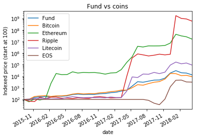

```python
date = '2015-09'
coins = ['Bitcoin', 'Ethereum', 'Ripple', 'Litecoin', 'EOS']
fund_vs_coins(date, coins)
plt.title('Fund vs coins')
plt.ylabel('Indexed price (start at 100)')
```

```python
assert b.T.sum().median() == 10
# check it looks ok
#b.T.sum().plot()
#plt.xlabel('Nr of coins in the fund')
#plt.show()
```

```python
# first date where nr of coins are 10
b[b.T.sum()==10].index.min()
```

```
Timestamp('2013-05-10 00:00:00')
```

## Summary statistics

Return, Vol, Return/Vol, etc.

```python
fundmean = fundret.mean()*12
fundvol = fundret.std()*np.sqrt(12)
fundmean / fundvol
```

```
1.093507168973481
```

```python
print("Annualized mean:", fundmean*100, "%",
      "Annualized vol:", fundvol*100, "%",
     "(Based on monthly data.)")
```

```
Annualized mean: 149.3698807399317 % Annualized vol: 136.597074969 % (Based on monthly data.)
```

```python
# day with max return
fundret.idxmax(), fundret[fundret.idxmax()]
```

```
(Timestamp('2013-12-10 00:00:00'), 1.7291597743451084)
```

```
Text(0.5,0,'Monthly return (not annualized)')
```

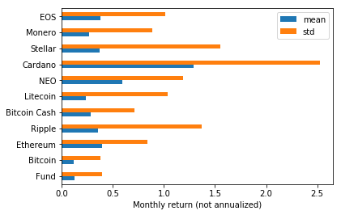

```python
rr = pd.concat([fundret, r[coins_top10]], axis=1)
rr_tmp = rr.replace(0, np.nan).apply([np.mean, np.std])
rr_tmp.T.plot.barh()
plt.xlabel('Monthly return (not annualized)')
# todo: annualize it
```

```python
rr.to_csv('ret_annualized_forcalendarfig.csv')
```

```python
def sharpe(returnseries):
    # with risk free = 0
    # which does not matter since we compare among coins and their rf is arguably the same, although unknown
    mean = 12*np.mean(returnseries)
    vol = np.sqrt(12)*np.std(returnseries)
    return np.round(mean/vol, 3)
```

```python
sharpelist = []
for coin in coins_top10:
    print(coin, sharpe(r[coin]))
    sharpelist.append((coin, sharpe(r[coin])))
```

```
Bitcoin 1.082
Ethereum 1.161
Ripple 0.874
Bitcoin Cash 0.498
Litecoin 0.793
NEO 0.922
Cardano 0.54
Stellar 0.714
Monero 0.928
EOS 0.504
```

## Returns

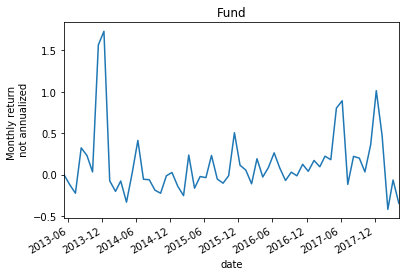

```python
fundret.plot()
plt.title('Fund')
plt.ylabel('Monthly return \n not annualized')
plt.show()
```

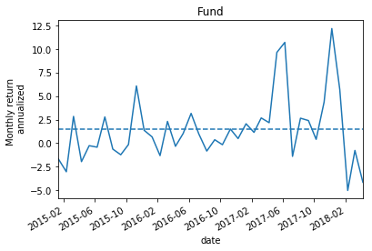

```python
fundret_annualized = 12*fundret
fundret_annualized.loc['2015':].plot()
plt.title('Fund')
plt.ylabel('Monthly return \n annualized')
plt.axhline(y=fundret_annualized.mean(), ls='--')
plt.show()
```

## Which coins are included?

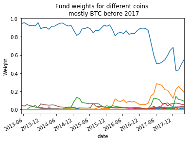

```python
w[coins_infund].plot(legend=False)
plt.title('Fund weights for different coins \n mostly BTC before 2017')
plt.ylabel('Weight')
plt.show()
# todo make a stacked bar chart
```

```python
k = 10
```

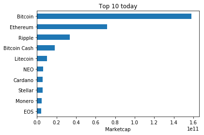

```python
# current top 10
mcap_mat.iloc[-2,:].sort_values(ascending=True).tail(k).plot.barh()
plt.title('Top ' + str(k) + ' today')
plt.xlabel('Marketcap')
plt.show()
```

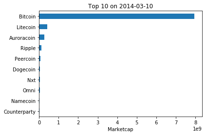

```python
# top k on a certain date
date = '2014-03-10'
mcap_mat.loc[date,:].sort_values(ascending=True).tail(k).plot.barh()
plt.title('Top ' + str(k) + ' on ' + date)
plt.xlabel('Marketcap')
plt.show()
```

## Correlations

```python
def corrplot(corr, annot=False):
    # Generate a mask for the upper triangle
    mask = np.zeros_like(corr, dtype=np.bool)
    mask[np.triu_indices_from(mask)] = True

    # Set up the matplotlib figure
    f, ax = plt.subplots(figsize=(11, 9))

    # Generate a custom diverging colormap
    cmap = sns.diverging_palette(220, 10, as_cmap=True)

    # Draw the heatmap with the mask and correct aspect ratio

    return sns.heatmap(corr, mask=mask, annot=annot, cmap=cmap, vmax=.3, center=0,
                square=True, linewidths=.5, cbar_kws={"shrink": .5})
```

```python
start_date = '2015-03'
end_date = '2018-03'
```

## coins in fund (monthly data)

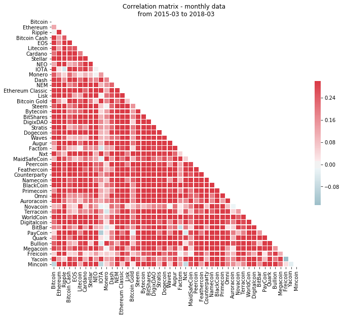

```python
# todo compute rolling corr matrix and plot
corrplot(corr=r[coins_infund].loc[start_date:end_date].corr())
plt.title('Correlation matrix - monthly data \n from ' + start_date + ' to ' + end_date)
plt.show()
```

## top 10 (monthly data)

```python
rr.head(3)
```

| date | Fund | Bitcoin | Ethereum | Ripple | Bitcoin Cash | Litecoin | NEO | Cardano | Stellar | Monero | EOS |
| --- | --- | --- | --- | --- | --- | --- | --- | --- | --- | --- | --- |
| 2013-05-10 | 0.000000 | 0.000000 | 0.0 | 0.0 | 0.0 | 0.000000 | 0.0 | 0.0 | 0.0 | 0.0 | 0.0 |
| 2013-06-10 | -0.122373 | -0.109574 | 0.0 | 0.0 | 0.0 | -0.302053 | 0.0 | 0.0 | 0.0 | 0.0 | 0.0 |
| 2013-07-10 | -0.223113 | -0.236161 | 0.0 | 0.0 | 0.0 | 0.096639 | 0.0 | 0.0 | 0.0 | 0.0 | 0.0 |

```
Text(0.5,1,'Correlation matrix - monthly data \n from 2015-03 to 2018-03')
```

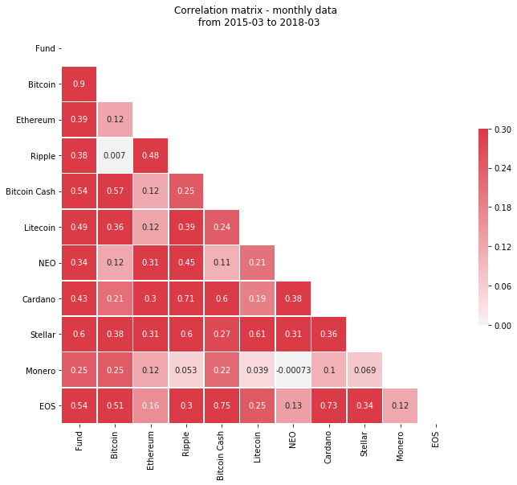

```python
corrplot(rr.loc[start_date:end_date].corr(), annot=True)
plt.title('Correlation matrix - monthly data \n from ' + start_date + ' to ' + end_date)
```

When I changed the `start_date` and `end_date` the correlation matrix did not change a lot. Some changes I did to these dates was to

- have a have start and end within 1y of each other (aka a 1y window length)
- keep the 3y window length but move back in time, e.g. 2014 to 2017.

```
Text(0.5,1,'Correlation matrix - monthly data \n from 2015-03 to 2018-03')
```

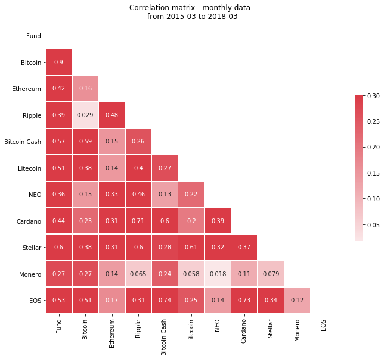

```python
start_date2 = '2015-03'
end_date2 = '2018-03'
corrplot(rr.loc[start_date2:].corr(), annot=True)
plt.title('Correlation matrix - monthly data \n from ' + start_date2 + ' to ' + end_date2)
```

There are statistical problems with using monthly data and 1y window, because then only 12 months are used to estimate the correlation - this sample can be considered small.

## Top 10 coins (daily data)

```
Text(0.5,1,'Correlation matrix - daily data \n from 2015-03 to 2018-03')
```

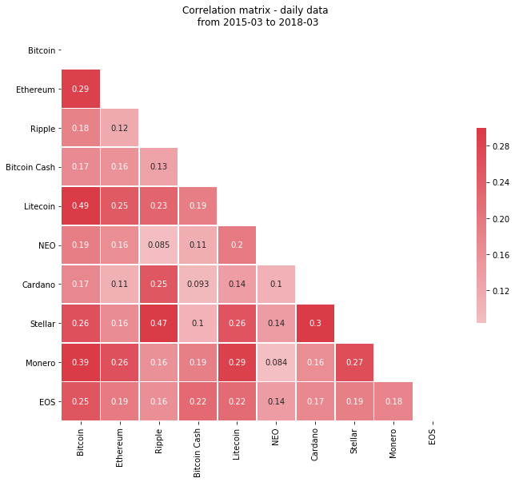

```python
r_top10_mat = returns_calc(daily_price_mat[coins_top10])
corr_top10daily = r_top10_mat.loc[start_date:end_date].corr()
corrplot(corr_top10daily, annot=True)
plt.title('Correlation matrix - daily data \n from ' + start_date + ' to ' + end_date)
```

Note that the correlations are closer to zero with daily data than with monthly data.

## Correlations over time

How do correlations change over time? For most financial assets they vary a lot over time.

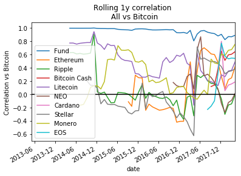

```python
# rolling corr with fundret and all top10 coins
fund_and_coins = pd.concat([rr.iloc[:,0], #fund returns
                            rr.iloc[:,2:]], #all coins except btc
                           axis=1)
bitcoin_returns = rr.iloc[:,1]
rollcorr = pd.rolling_corr(bitcoin_returns, fund_and_coins, window=12)
rollcorr_old = pd.rolling_corr(rr.iloc[:,0], rr.iloc[:,1:], window=12) #when comparing fund vs coins
rollcorr.to_csv('rollcorr.csv', na_rep='NaN')
rollcorr.plot()
plt.ylabel('Correlation vs Bitcoin')
plt.title('Rolling 1y correlation \n All vs Bitcoin')
plt.axhline(y=0, color='k', ls='-')
```

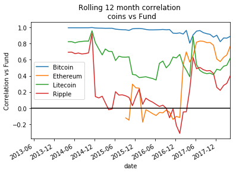

```python
rollcorr_old[coins_comp].plot()
plt.ylabel('Correlation')
plt.title('Rolling 12 month correlation \n coins vs Fund')
plt.ylabel('Correlation vs Fund')
plt.axhline(y=0, color='k', ls='-')
```

Now we turn to daily data. For this set we do not have a fund. So here we calculate all correlations vs bitcoin. It will be a bit hard to compare monthly vs daily, since one with fund vs coins and another in bitcoin vs fund, but it's ok. (An alternative is to for monthly compare bitcoin vs fund&coins and for daily compare bitcoin & coins, but I think that's not as good).

```python
rollcorr_daily = pd.rolling_corr(r_top10_mat.iloc[:,0], r_top10_mat.iloc[:,1:], window=250)
print("Monthly vs daily, in size: ", rollcorr.shape, rollcorr_daily.shape)
```

```
Monthly vs daily, in size:  (60, 10) (1800, 9)
```

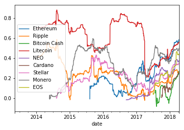

```python
rollcorr_daily.plot()
```

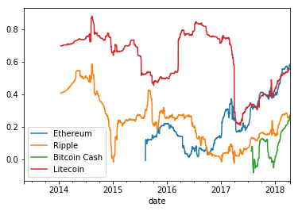

```python
rollcorr_daily[['Ethereum', 'Ripple', 'Bitcoin Cash', 'Litecoin']].plot()
```

## correlation: crypto vs traditional finance

```python
fin_p = pd.read_excel('data-financial/price_tradfinance.xlsx', index_col=0, parse_dates=True)
```

```python
fin_p.columns = ['SP500', 'OMXS30', 'EURSTOXX', 'Gold']
```

```python
# drop rows if any col has NA
fin_p.dropna(inplace=True)
```

```python
fin_r = returns_calc(fin_p)
```

```python
fin_r.isnull().sum()
```

```
SP500       0
OMXS30      0
EURSTOXX    0
Gold        0
dtype: int64
```

```python
# daily data, but only business calendar days
fin_r.index
```

```
DatetimeIndex(['2012-01-03', '2012-01-04', '2012-01-05', '2012-01-09',
               '2012-01-10', '2012-01-11', '2012-01-12', '2012-01-13',
               '2012-01-17', '2012-01-18',
               ...
               '2018-03-26', '2018-03-27', '2018-03-28', '2018-03-29',
               '2018-04-03', '2018-04-04', '2018-04-05', '2018-04-06',
               '2018-04-09', '2018-04-10'],
              dtype='datetime64[ns]', name='Date', length=1531, freq=None)
```

```python
# reindex to inlcude all claendar days, using forward fill
fin_r = fin_r.reindex(r_top10_mat.index, method='ffill')
assert (fin_r.index == r_top10_mat.index).all()
```

```python
# create monthly data
fin_r_monthly = fin_r.loc[fin_r.index.day == 10]
```

```python
start_date, end_date
```

```
('2015-03', '2018-03')
```

### traditional - daily , 3y

```
Text(0.5,1,'Correlation matrix - daily data \n from 2015-03 to 2018-03')
```

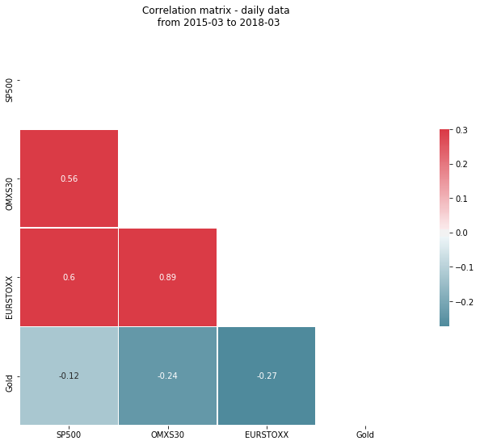

```python
corrplot(fin_r.loc[start_date:end_date].corr(), annot=True)
plt.title('Correlation matrix - daily data \n from ' + start_date + ' to ' + end_date)
```

### traditional - monthly, 3y

```
Text(0.5,1,'Correlation matrix - monthly data \n from 2015-03 to 2018-03')
```

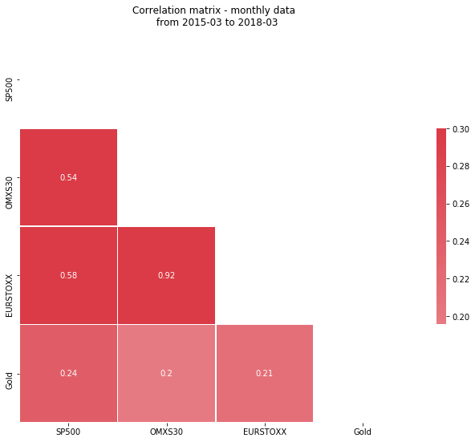

```python
corrplot(fin_r_monthly.loc[start_date:end_date].corr(), annot=True)
plt.title('Correlation matrix - monthly data \n from ' + start_date + ' to ' + end_date)
```

### traditional vs crypto, monthly

```python
# Will not use `r_top10_mat` because it has .fillna(0) and that does not suit our needs here.
r_top10_mat_na = returns_calc(price_mat[coins_top10], fill_na_0=False)

# concat the above with return for financial assets: both have monthly data
fin_coins_r = pd.concat([fin_r_monthly.loc[start_date:end_date], #financial assets
           r_top10_mat_na.loc[start_date:end_date], # top 10 crypto assets
                         fundret[start_date:end_date] # fund return
                        ], axis=1, join='inner')
```

```python
# monthly data
fin_coins_r.index
assert (fin_coins_r.index == fin_r_monthly[start_date:end_date].index).all()
```

```python
print(len(fin_coins_r), " months")
```

```
37  months
```

```python
# there are NAs
fin_coins_r.isnull().sum()
```

```
SP500            0
OMXS30           0
EURSTOXX         0
Gold             0
Bitcoin          0
Ethereum         5
Ripple           0
Bitcoin Cash    29
Litecoin         0
NEO             18
Cardano         31
Stellar          0
Monero           0
EOS             28
Fund             0
dtype: int64
```

There are NAs. Those will be pairwise ignored. Todo: make sure by reading the docs again that this is how it is handled. You could also make a corrplot with dropped NAs.

```
Text(0.5,1,'Correlation matrix - monthly data \n from 2015-03 to 2018-03')
```

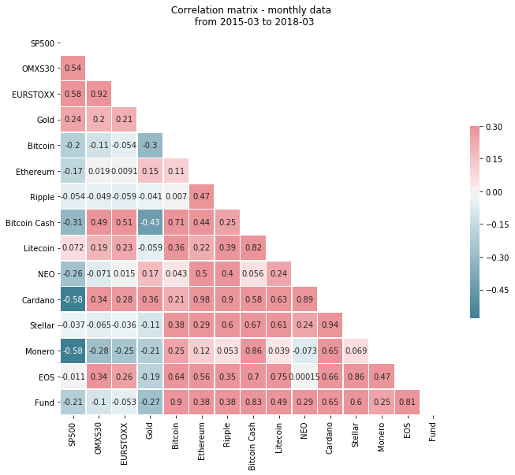

```python
corrplot(fin_coins_r.corr(), annot=True)
plt.title('Correlation matrix - monthly data \n from ' + start_date + ' to ' + end_date)
```

1. To compare coins vs coins, look in the lower right corner
2. To copmare traditional vs traditionl, look in the top left corner
3. to compare coins vs traditional, look in the left bottom corner

todo: make a for loop and print as files, then look at them superfast => nice movie.

### traditional vs crypto, rolling

```python
selection = ['SP500', 'Gold', 'Fund', 'Ethereum']
pd.rolling_corr(fin_coins_r[selection], window=12).to_csv('rollcorr_tradvscoins.csv', na_rep='NaN')
```

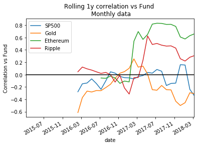

```python
selection2 = ['SP500', 'Gold', 'Ethereum', 'Ripple']
pd.rolling_corr(fin_coins_r['Fund'], fin_coins_r[selection2], window=12).plot()
plt.title('Rolling 1y correlation vs Fund \n Monthly data')
plt.ylabel('Correlation vs Fund')
plt.axhline(y=0, color='k', ls='-')
```

Correlations are not stable over time, just like it usually is. It is important that they don't all go to 1 in some periods. Thus the output is good news.

## market cap covered by the fund

see the function for how `fundmcap` was created

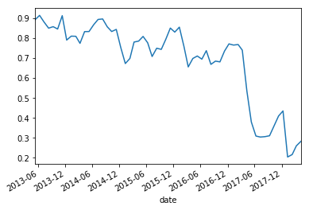

```python
totmcap = mcap_mat.T.sum()
fund_fraq_mcap = fundmcap / totmcap
fund_fraq_mcap.plot()
```

```
Text(0.5,1,'Market cap covered by the fund')
```

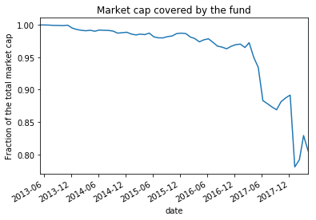

```python
fund_mcap_fraq_binary = fundmcap_binary / totmcap
fund_mcap_fraq_binary.name = 'Fund'
fund_mcap_fraq_binary.plot()
plt.ylabel('Fraction of the total market cap')
plt.title('Market cap covered by the fund')
```

```python
btc_mcap_fraq = mcap_mat['Bitcoin'] / totmcap
eth_mcap_fraq = mcap_mat['Ethereum'] / totmcap
```

```
Text(0.5,1,'Market cap covered by the fund \n exceeds Bitcoin and Ethereum')
```

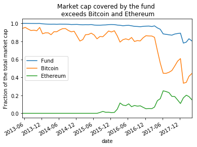

```python
mcapcomp = pd.concat([fund_mcap_fraq_binary, btc_mcap_fraq, eth_mcap_fraq], axis=1)
mcapcomp.columns = ['Fund', 'Bitcoin', 'Ethereum']
mcapcomp.plot()
plt.ylabel('Fraction of the total market cap')
plt.title('Market cap covered by the fund \n exceeds Bitcoin and Ethereum')
```

it is not sufficient to hold only btc and eth to capture the market

```
Text(0,0.5,'Market cap in $')
```

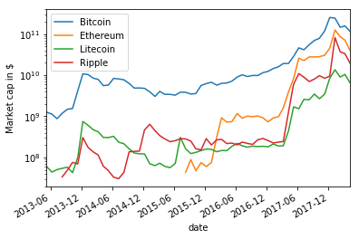

```python
mcap_mat[coins_comp].plot(logy=True)
plt.ylabel('Market cap in $')
```

## 3). Number of coins that has been in top 10 that today is out of top 50 and top 100 last 5 years

```python
# last day is -2
coins_mcap_today = mcap_mat.iloc[-2]
coins_mcap_today = coins_mcap_today.sort_values(ascending=False)
```

```python
# coins that are out of top 50 today
coins_mcap_today[50:].index
```

```
Index(['KuCoin Shares', 'Dragonchain', 'Syscoin', 'Hshare', 'Zilliqa', 'Gas',
       'PIVX', 'Basic Attention Token', 'Golem', 'DigiByte',
       ...
       'Bastonet', 'BigONE Token', 'Candy', 'United Bitcoin', 'Titanium BAR',
       'StockChain', 'BitcoinX', 'Aidos Kuneen', 'BitRent', 'W3Coin'],
      dtype='object', length=1512)
```

```python
# coins that has once been in the fund
len(coins_infund)
```

```
47
```

```python
intersection = set(coins_mcap_today[50:].index) & set(coins_infund)
len(intersection)
```

```
23
```

```python
print(len(coins_infund), "different coins has been in top 10. Out of these,",
      len(intersection),"are now outside top 50." )
```

```
47 different coins has been in top 10. Out of these, 23 are now outside top 50.
```